# Likelihood-aware stock mixture

Research prototype - methodological review requested

Published

September 18, 2026

## Review in brief

The prototype extends a **discrete population mixture** to diploid biallelic genotype likelihoods (GL/PL), with blockwise GDS input, multiple starts and optional pooled regularization. It is not an admixture model. Genetic clusters alone do not establish demographically independent management stocks.

**The positive result:** likelihood-aware assignment can retain useful information at low coverage. **The unresolved result:** selecting the true number of groups is not reliably calibrated, particularly under weak differentiation or null data. Convergence, confident membership and agreement between folds do not certify a biologically correct partition.

Scott’s permission to use his code is appreciated. This document requests his methodological and implementation review; it does not imply endorsement.

### What the experiments support

- No universal 10-fold coverage requirement emerged. At simulated drift $F=0.005$, known-$K$ assignment improved substantially between 2-fold and 5-fold coverage; the benefit of extra depth then diminished in this design.
- GL outperformed the tested hard-call rule at intermediate coverage. This is a matched simulation comparison, not a comparison against every variant caller.
- Low differentiation remained difficult even with true genotypes. Oracle frequencies recovered much more structure, implicating frequency estimation from limited training samples as an important limitation.
- Automatic predictive $K$ selection can split null data. A separate six-null experiment at 1-fold coverage selected $K>1$ in five cases. This small count is a warning, not a precise general false-positive rate.

### Decision requested

Keep this internal and experimental. Review the model and optimization first; then freeze the method before fresh, independent calibration experiments. Neither a public stock-delineation claim nor an automatic confidence threshold is justified by the present evidence.

## Model and implementation

For individual $i$, marker $l$ and component $k$, the likelihood is

$$P(D_i)=\sum_k\pi_k\prod_l\sum_{g=0}^2
L_{ilg}{2\choose g}p_{lk}^{g}(1-p_{lk})^{2-g}.$$

Here $g$ is alternate-allele dosage and $L_{ilg}$ is the genotype likelihood. The model assumes Hardy-Weinberg equilibrium within components and conditional independence across markers. EM estimates component frequencies and proportions. The extension builds on the stockR mixture framework, rather than its admixture interpretation or a verbatim implementation (Foster and colleagues, 2018).

Optional pooled regularization adds $s\sum_{lk}[q_l\log p_{lk}+(1-q_l)\log(1-p_{lk})]$, where $q_l$ is estimated from training data alone and held fixed during the fit. This corresponds to Beta parameters $1+s q_l$ and $1+s(1-q_l)$. The frequency update adds $s q_l$ to the expected alternate count and $s$ to the informative allele-count denominator.

Starts are ranked by the penalized objective within a fit. Held-out prediction uses marginal data log likelihood, not the penalty. Penalized objectives are not a criterion for comparing different $K$ or prior settings.

### Operational safeguards

- GDS is read in marker blocks. Owned handles open read-only; borrowed handles remain open and active filters are restored.
- Automatic input selection prefers PL, then GL. There is no silent GT or GP fallback. The hard-genotype benchmarks encode calls as near-certain likelihoods; they do not establish a direct GT input API.
- Flat or fully missing likelihoods are neutral. They do not contribute to allele-frequency updates. Entirely uninformative individuals receive no assignment; malformed likelihood vectors are rejected.
- Zero-weight held-out individuals do not estimate frequencies, the pooled center, mixture proportions or initial partitions. STRATA is descriptive metadata, not a fitting predictor.
- Streaming reduces genotype memory, but frequency and membership matrices remain in memory. Initialization has separate memory guards.

### Experimental settings are not defaults

Recent pilots used pooled strength 500, seven blind starts, all-marker PCA initialization and strict convergence settings. The internal interface defaults to no regularization and random starts; its initialization marker limit differs. Strength 500 is not a validated general recommendation.

## Coverage and genotype representation

The matched pilot used 3,000 independent SNPs, 150 training individuals (50 per group), 300 independent test individuals and two frequency realizations per condition. Reads had known error probability 0.01. Depths shared underlying genotypes. The simulation’s drift $F$ is **not measured WC84 $F_{ST}$**.

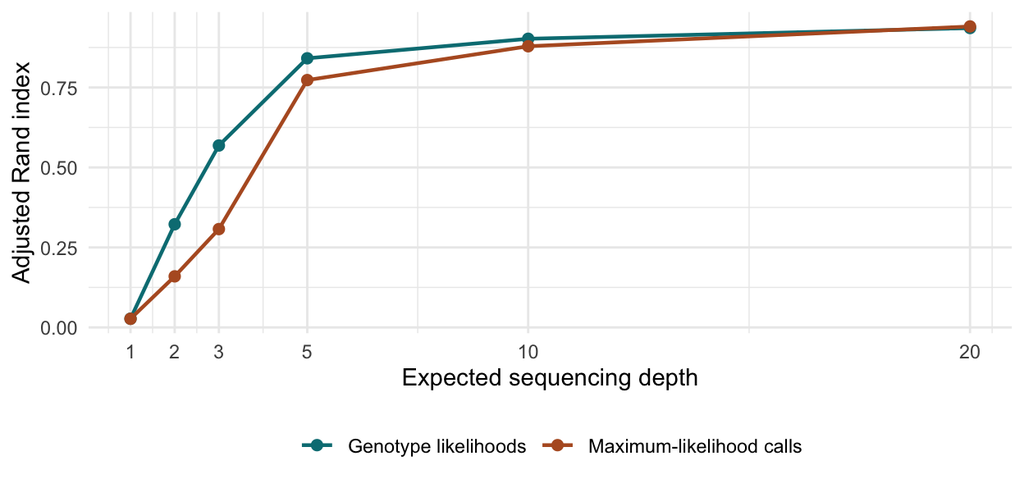

Independent-test assignment with K fixed at 3, drift F = 0.005. Means of two realizations; not confidence intervals.

At 3-fold coverage, GL mean test ARI was 0.569 versus 0.307 for maximum-likelihood calls; at 5-fold it was 0.841 versus 0.773. At 20-fold the values were 0.936 and 0.941, too close in this small pilot to claim general GT superiority. ARI measures partition agreement with simulated truth and is approximately zero at chance.

Strict calling required a normalized genotype likelihood of at least 0.99, equivalent to an equal-genotype-prior rule, **not production-caller GQ**. It retained only 8.8% of calls at 3-fold coverage and 30.6% at 5-fold, sacrificing substantial information. Missing calls were not replaced with reference genotypes.

These are known-$K$ results. Success when $K=3$ is supplied does not validate automatic recovery of $K$. Raw prediction scores across different representations are not directly comparable; the experiment also retained common-target scores.

## Why weak structure remains difficult

At drift $F=0.001$, blind true-genotype fits gave chance-level test assignment. The following controls separate unavailable knowledge from deployable methods:

| True-genotype control, K = 3 | Mean test ARI |
| --- | --- |
| Blind pooled fit | approximately 0.000 |
| Frozen generating frequencies (oracle) | 0.806 |
| True training labels, estimated frequencies | 0.146 |
| Generating-frequency start, then EM | 0.151 |

Two realizations; strength 500 where frequencies were estimated. The oracle uses privileged generating frequencies and is not an operational solution. The supervised control uses training labels only, not test labels. These results implicate finite-sample frequency estimation; they do not prove that recovery is information-theoretically impossible.

Blind fits had higher training objectives than the better-generalizing truth-start fits. More starts alone therefore cannot be assumed to fix the problem. Removing regularization increased confidence without reliably improving accuracy. Conditional beta-binomial prediction and a separate joint variational pilot did not rescue weak-group recovery. Both used true GT and a restricted $K\in\{1,3\}$ comparison; neither is adopted or resolves GL null splitting.

## Technical heterogeneity

The latest paired pilot used two null and two structured realizations, the same sample sizes and 3,000 SNPs. Technical batches coincided with biological groups only in structured data. Extra masks were genotype-independent within batch; this did not simulate allele dropout or reference bias.

| Condition | Test ARI, K fixed at 3 |
| --- | --- |
| Batch depths 1 / 3 / 5 | 0.261 |
| Uniform 3-fold depth | 0.614 |
| Batch extra 10 / 30 / 50% missing | 0.107 |
| Random extra 30% missing | 0.162 |

Uniform depth and heterogeneous depth have the same expected mean of 3-fold. The masked arms retain about 2.1-fold average depth. Structured missingness was worse on average, not in every replicate. There was no demonstrated increase in null splitting over the matched controls in this small experiment. One wrong $K=2$ solution nevertheless had agreeing fold winners and mean maximum membership 0.825: those diagnostics are not guarantees of correctness.

## Safeguards and questions for Scott

Current reporting separates the numerical predictive winner from its support: fold winners (including ties), score gaps, grid-boundary flags, incomplete comparisons and fit warnings. Start agreement is label-invariant and reports the number of comparable individuals. Memory-limited non-assessment is explicit. Individual output includes membership margin, entropy and assignment status.

These are descriptive safeguards, not calibrated acceptance rules. Agreement between fold $K$ winners is not across-fold membership stability. A single near-best start cannot demonstrate near-optimal stability. $K=1$ means no selected split under the tested rule, not proof of panmixia.

### Requested review

1. **Likelihood and EM:** Are the genotype ordering, missing-information treatment, weighted updates and GL/PL extension faithful to the intended mixture model?
2. **Regularization:** Is training-only pooled shrinkage scientifically appropriate, and what tuning/uncertainty treatment would be defensible with limited fish?
3. **Choosing K:** What calibrated alternative or abstention strategy should replace an unqualified maximum predictive-score winner under weak and null structure?
4. **Uncertainty:** Which diagnostics or resampling scheme can quantify assignment reliability while allowing linkage, relatedness and estimation uncertainty?
5. **Scope:** What evidence and independent validation would be needed before exposing this as a public assigner function?

### Next validation, after methodological review

Freeze fitting and selection choices; test new independent realizations under unequal sampling, relatedness, linkage, depth error, allele-dependent missingness and reference bias. Include measured differentiation, realistic GL generation and external datasets. Reusing pilots to choose methods makes them developmental, not confirmatory validation. Management-stock independence additionally requires demographic and ecological evidence outside this mixture model.

### Reference

Foster SD, Feutry P, Grewe PM, Berry O, Hui FKC, Davies CR (2018). Reliably discriminating stock structure with genetic markers: Mixture models with robust and fast computation. *Molecular Ecology Resources*, 18, 1310-1325. https://doi.org/10.1111/1755-0998.12920

## Appendix: code and reproducibility review

This is internal inspection, not independent certification or a complete R CMD check. The latest targeted run passed 28 tests with no failed expectations or errors (18 September 2026).

| Area | Checks present in the targeted test suite |
| --- | --- |
| Likelihoods | GL/PL equivalence; hard-call binomial identity; neutral missingness; malformed input |
| Computation | Scalar/streamed equivalence; block sizes; weighted and penalized updates |
| Leakage | Training-only starts and pooled center; zero-weight holdouts |
| GDS | Identifier alignment; filter restoration; handle cleanup on errors |
| Reproducibility | RNG restoration; failed starts retained; seed propagation |
| Reporting | Label-invariant ARI; ties; entropy/margin; incomplete comparisons |

### Remaining limitations found in inspection

- The scalar core header still describes CV/bootstrap as absent; separate utilities now exist. This is documentation drift, recorded here rather than silently edited.
- Numerical frequency support above a tiny tolerance is not evidence of adequate biological sample size or allele-frequency precision.
- Cross-validation does not repeat upstream marker selection/QC within folds. Overlapping training folds do not supply independent confidence intervals.
- The bootstrap is fixed-$K$, whole-individual resampling, not stockBOOT Bayesian resampling. Its low-coverage interval coverage has not been established. Failed replicates invalidate interval reporting rather than being silently dropped.
- No current diagnostic calibrates an operational reject/abstain threshold.

### Rebuilding and provenance

Render `review.qmd` using Quarto. It reads `data/review-results.rds`, never reruns simulations. `prepare-review.R` refreshes compact saved results and source copies. Historical benchmark source hashes and complete per-panel outputs remain in the original experiment directories. Current snapshot hashes must not be substituted for historical benchmark hashes.

This compact package is not the full raw-data reproduction archive. Obtain the original experiment directories and runners before independent reproduction.